# Matplotlib图表美化与标注教学

## 教学目标

面向大一文科生讲解Matplotlib图表的美化技巧与标注方法，使数据可视化更加专业、美观且易于理解。

## 1. 图表美化基础

### 1.1 定义与重要性

**定义**：图表美化是通过调整视觉元素（颜色、字体、布局等）提升图表可读性和美观度的过程。

**人文社科意义**：

- 增强学术报告的专业性
- 突出关键数据发现
- 使复杂数据更易于理解
- 符合出版物的视觉要求

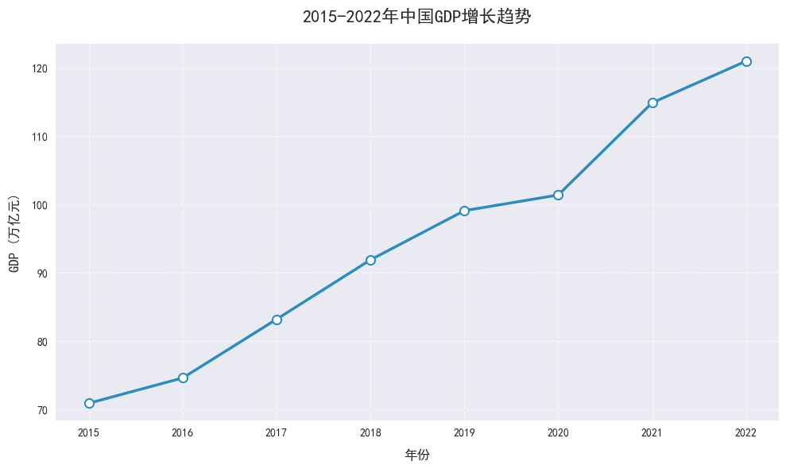

```python
import matplotlib.pyplot as plt
import numpy as np

# 设置全局样式（在绘图前调用）
plt.style.use('seaborn')  # 使用seaborn风格
plt.rcParams['font.sans-serif'] = ['SimHei']  # 设置中文字体
plt.rcParams['axes.unicode_minus'] = False  # 解决负号显示问题

# 创建示例数据
years = np.arange(2015, 2023)
gdp = [70.9, 74.6, 83.2, 91.9, 99.1, 101.4, 114.9, 121.0]  # 单位：万亿元

# 绘制基础图表并美化
plt.figure(figsize=(10, 6), dpi=100)  # 设置画布大小和分辨率
plt.plot(years, gdp,
         color='#2b8cbe',  # 使用HEX颜色代码
         linewidth=2.5,
         marker='o',
         markersize=8,
         markerfacecolor='white',
         markeredgewidth=1.5)

# 添加标题和标签（美化版）
plt.title('2015-2022年中国GDP增长趋势',
          fontsize=16,
          pad=20)
plt.xlabel('年份', fontsize=12, labelpad=10)
plt.ylabel('GDP (万亿元)', fontsize=12, labelpad=10)
plt.grid(True, linestyle='--', alpha=0.6)
plt.xticks(fontsize=10)
plt.yticks(fontsize=10)
plt.tight_layout()
plt.show()
```

## 2. 图表标注技巧

### 2.1 文字标注

**人文社科应用**：标注重大事件对数据的影响

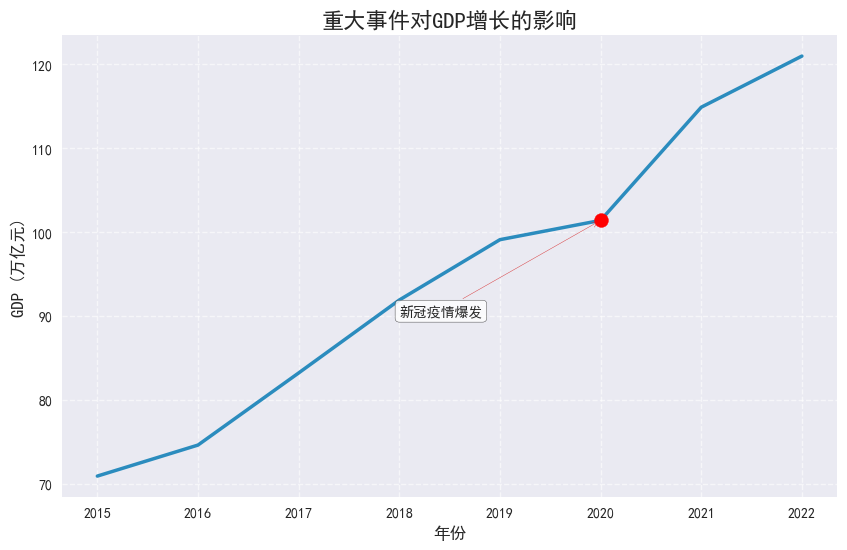

```python
# 继续使用前面的GDP数据
plt.figure(figsize=(10, 6))
plt.plot(years, gdp, color='#2b8cbe', linewidth=2.5)
plt.annotate('新冠疫情爆发',
             xy=(2020, 101.4),
             xytext=(2018, 90),
             arrowprops=dict(arrowstyle='->', color='#d62728'),
             fontsize=10,
             bbox=dict(boxstyle='round', facecolor='white', alpha=0.8))
plt.scatter(2020, 101.4, color='red', s=100, zorder=5)
plt.title('重大事件对GDP增长的影响', fontsize=16)
plt.xlabel('年份', fontsize=12)
plt.ylabel('GDP (万亿元)', fontsize=12)
plt.grid(True, linestyle='--', alpha=0.6)
plt.show()
```

### 2.2 图例美化

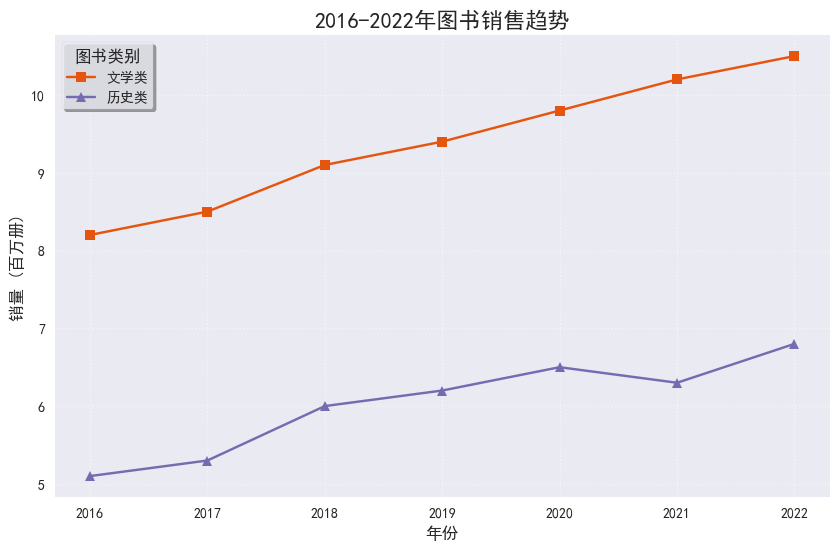

```python
# 多系列数据示例
literature = [8.2, 8.5, 9.1, 9.4, 9.8, 10.2, 10.5]  # 文学类图书销量（百万册）
history = [5.1, 5.3, 6.0, 6.2, 6.5, 6.3, 6.8]  # 历史类
years = np.arange(2016, 2023)

plt.figure(figsize=(10, 6))
line1, = plt.plot(years, literature, color='#e6550d', marker='s', label='文学类')
line2, = plt.plot(years, history, color='#756bb1', marker='^', label='历史类')

# 美化图例
plt.legend(handles=[line1, line2],
           loc='upper left',
           frameon=True,  # 显示边框
           shadow=True,  # 添加阴影
           framealpha=0.8,  # 透明度
           title='图书类别',  # 图例标题
           title_fontsize=12,
           fontsize=10)

plt.title('2016-2022年图书销售趋势', fontsize=16)
plt.xlabel('年份', fontsize=12)
plt.ylabel('销量 (百万册)', fontsize=12)
plt.grid(True, linestyle=':', alpha=0.5)  # 点线网格
plt.show()
```

## 3. 人文社科案例实战

### 3.1 调查数据可视化

案例：大学生阅读习惯调查结果美化

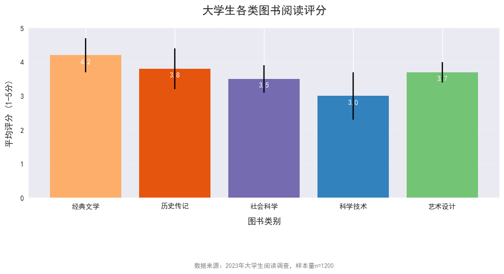

```python
# 调查数据
categories = ['经典文学', '历史传记', '社会科学', '科学技术', '艺术设计']
ratings = [4.2, 3.8, 3.5, 3.0, 3.7]  # 平均评分（1-5分）
std_dev = [0.5, 0.6, 0.4, 0.7, 0.3]  # 标准差

plt.figure(figsize=(10, 6))
bars = plt.bar(categories, ratings,
               color=['#fdae6b', '#e6550d', '#756bb1', '#3182bd', '#74c476'],
               yerr=std_dev,  # 添加误差条
               capsize=5)  # 误差条端帽长度

# 添加数值标签
for bar in bars:
    height = bar.get_height()
    plt.text(bar.get_x() + bar.get_width()/2., height-0.1,
             f'{height:.1f}',
             ha='center', va='top',
             color='white', fontsize=10, fontweight='bold')

# 美化图表
plt.title('大学生各类图书阅读评分', fontsize=16, pad=20)
plt.xlabel('图书类别', fontsize=12, labelpad=10)
plt.ylabel('平均评分 (1-5分)', fontsize=12, labelpad=10)
plt.ylim(0, 5)  # 固定y轴范围
plt.grid(axis='y', linestyle='--', alpha=0.3)

# 添加数据来源说明
plt.text(0.5, -0.4, '数据来源：2023年大学生阅读调查，样本量n=1200',
         ha='center', va='center',
         transform=plt.gca().transAxes,  # 使用相对坐标
         fontsize=9, color='gray')

plt.tight_layout()
plt.show()
```